# 03-model-training

```
<class 'pandas.core.frame.DataFrame'>
Index: 2707 entries, 0 to 2706
Columns: 117 entries, date to cumulative_profit
dtypes: float64(113), int64(1), object(3)
memory usage: 2.4+ MB
```

|  | date | adj_close | close | high | low | open | volume | ticker | revenues | cost_of_goods | ... | normalized_net_income | 30_DMA | 10_DMA | 10_Day_Avg | Next_10_Day_Avg | signal | stock_quantity | total_buy_price | stock_profit | cumulative_profit |
| --- | --- | --- | --- | --- | --- | --- | --- | --- | --- | --- | --- | --- | --- | --- | --- | --- | --- | --- | --- | --- | --- |
| 0 | 2010-04-01 | 7.108997 | 8.427500 | 8.526071 | 8.312500 | 8.478929 | 603145200 | AAPL | 13499000.0 | 7874000.0 | ... | 0.0 | 8.427500 | 8.427500 | NaN | 8.668214 | BUY | 1.0 | 8.427500 | 0.0 | 0.0 |
| 1 | 2010-04-05 | 7.184915 | 8.517500 | 8.518214 | 8.384643 | 8.392143 | 684507600 | AAPL | 13499000.0 | 7874000.0 | ... | 0.0 | 8.472500 | 8.472500 | NaN | 8.698857 | BUY | 2.0 | 16.945000 | 0.0 | 0.0 |
| 2 | 2010-04-06 | 7.216546 | 8.555000 | 8.580000 | 8.464286 | 8.507143 | 447017200 | AAPL | 13499000.0 | 7874000.0 | ... | 0.0 | 8.500000 | 8.500000 | NaN | 8.716893 | BUY | 3.0 | 25.500000 | 0.0 | 0.0 |
| 3 | 2010-04-07 | 7.248483 | 8.592857 | 8.640000 | 8.523571 | 8.555357 | 628502000 | AAPL | 13499000.0 | 7874000.0 | ... | 0.0 | 8.523214 | 8.523214 | NaN | 8.783393 | BUY | 4.0 | 34.092857 | 0.0 | 0.0 |
| 4 | 2010-04-08 | 7.228898 | 8.569643 | 8.626429 | 8.501429 | 8.587143 | 572989200 | AAPL | 13499000.0 | 7874000.0 | ... | 0.0 | 8.532500 | 8.532500 | NaN | 8.878107 | BUY | 5.0 | 42.662500 | 0.0 | 0.0 |

5 rows × 117 columns

|  | signal | close | 10_DMA | cumulative_profit | debt_to_equity_ratio | price_to_book_value | other_assets | market_capitalization | research_&_development | enterprise_valuation | common_stock | property_plant_&_equipment | PC1 | PC2 | PC3 | PC4 |
| --- | --- | --- | --- | --- | --- | --- | --- | --- | --- | --- | --- | --- | --- | --- | --- | --- |
| 0 | 1 | 8.427500 | 8.427500 | 0.000000 | 0.450061 | 5.415465 | 5569000.0 | 2.130877e+08 | 426000.0 | 2.030697e+08 | 9553000.0 | 3504000.0 | 8.080048e+08 | 6.713907e+07 | -7.000018e+07 | 6.825490e+07 |
| 1 | 1 | 8.517500 | 8.472500 | 0.000000 | 0.450061 | 5.415465 | 5569000.0 | 2.130877e+08 | 426000.0 | 2.030697e+08 | 9553000.0 | 3504000.0 | 8.371229e+08 | 1.369311e+08 | -4.025388e+07 | 7.162174e+07 |
| 2 | 1 | 8.555000 | 8.500000 | 0.000000 | 0.450061 | 5.415465 | 5569000.0 | 2.130877e+08 | 426000.0 | 2.030697e+08 | 9553000.0 | 3504000.0 | 7.521293e+08 | -6.678632e+07 | -1.270810e+08 | 6.179421e+07 |
| 3 | 1 | 8.592857 | 8.523214 | 0.000000 | 0.450061 | 5.415465 | 5569000.0 | 2.130877e+08 | 426000.0 | 2.030697e+08 | 9553000.0 | 3504000.0 | 8.170795e+08 | 8.888993e+07 | -6.072967e+07 | 6.930419e+07 |
| 4 | 1 | 8.569643 | 8.532500 | 0.000000 | 0.450061 | 5.415465 | 5569000.0 | 2.130877e+08 | 426000.0 | 2.030697e+08 | 9553000.0 | 3504000.0 | 7.972125e+08 | 4.127149e+07 | -8.102530e+07 | 6.700703e+07 |
| ... | ... | ... | ... | ... | ... | ... | ... | ... | ... | ... | ... | ... | ... | ... | ... | ... |
| 2702 | 0 | 130.960007 | 126.955000 | 4631.666698 | 3.085432 | 13.914162 | 49559000.0 | 1.091218e+09 | 4565000.0 | 1.150788e+09 | 48032000.0 | 43986000.0 | -6.823723e+08 | 1.188443e+08 | -1.359444e+08 | 2.422274e+07 |
| 2703 | 0 | 131.970001 | 127.828001 | 4631.666698 | 3.085432 | 13.914162 | 49559000.0 | 1.091218e+09 | 4565000.0 | 1.150788e+09 | 48032000.0 | 43986000.0 | -6.942875e+08 | 9.028531e+07 | -1.481166e+08 | 2.284502e+07 |
| 2704 | 0 | 136.690002 | 129.256001 | 4631.666698 | 3.085432 | 13.914162 | 49559000.0 | 1.091218e+09 | 4565000.0 | 1.150788e+09 | 48032000.0 | 43986000.0 | -6.693946e+08 | 1.499500e+08 | -1.226867e+08 | 2.572331e+07 |
| 2705 | 0 | 134.869995 | 130.565000 | 4631.666698 | 3.085432 | 13.914162 | 49559000.0 | 1.091218e+09 | 4565000.0 | 1.150788e+09 | 48032000.0 | 43986000.0 | -6.706253e+08 | 1.470001e+08 | -1.239440e+08 | 2.558100e+07 |
| 2706 | 0 | 133.720001 | 131.149001 | 4631.666698 | 3.085432 | 13.914162 | 49559000.0 | 1.091218e+09 | 4565000.0 | 1.150788e+09 | 48032000.0 | 43986000.0 | -6.794275e+08 | 1.259026e+08 | -1.329361e+08 | 2.456324e+07 |

2707 rows × 16 columns

## LSTM Model (with just Close price)

### **Overview**

This model focuses on predicting stock prices using a **Long Short-Term Memory (LSTM)** neural network. LSTM is a type of Recurrent Neural Network (RNN) designed to learn from sequential data, making it particularly well-suited for time-series forecasting problems like stock price prediction.

### **Why Use LSTM for Stock Price Prediction?**

#### **1. Handling Sequential Data**

- **Stock prices are time-dependent**: Historical stock prices are a sequence where each value depends on previous values. Traditional models like linear regression fail to capture this temporal dependency, but LSTM can.

#### **2. Memory Retention**

- **Captures long-term dependencies**: Unlike regular RNNs, which suffer from short-term memory issues, LSTM is designed to **retain long-term patterns** using mechanisms like **cell states** and **gates** (input, output, forget).

#### **3. Handling Noisy Data**

- **Robustness to noise**: Stock price data can be noisy, with sudden fluctuations. LSTM's ability to generalize over long periods makes it more robust in predicting trends amidst noise.

### **Key Steps in the Process**

#### **1. Data Normalization**

- Stock price data is scaled to a range between **0 and 1** using **MinMaxScaler**. This ensures that all input values are comparable, which enhances the LSTM model's performance and speeds up training convergence.

#### **2. Dataset Preparation**

- The dataset is structured into input-output pairs, where:
  - **Input (`X`)**: A sequence of historical prices over a defined **look-back period**.
  - **Output (`Y`)**: The price immediately following the sequence.

#### **3. Train-Test Split**

- The data is split into **training** (80%) and **testing** (20%) sets to evaluate the model's generalization capabilities. This prevents overfitting and ensures reliable performance on unseen data.

### **LSTM Model Architecture**

#### **1. Input Layer**

- The input consists of **sequences of historical prices** represented as 3D arrays: `[samples, time steps, features]`.

#### **2. LSTM Layers**

- Two stacked LSTM layers are used:
  - **First LSTM Layer**: Outputs sequences to the next LSTM layer (`return_sequences=True`).
  - **Second LSTM Layer**: Outputs a single vector summarizing the learned information.

#### **3. Dense Layer**

- A fully connected layer with one neuron is added to predict the next stock price based on the output from the LSTM layers.

### **Model Compilation & Training**

#### **Loss Function**

- The model is optimized using **Mean Squared Error (MSE)**, a standard loss function for regression problems, minimizing the average squared difference between predicted and actual values.

#### **Optimizer**

- The **Adam optimizer** is chosen for its adaptive learning rate, which ensures faster and more stable convergence.

#### **Training Parameters**

- The model is trained for **30 epochs** with a **batch size of 32**, balancing between computational efficiency and model performance.

### **Advantages of Using LSTM for Stock Prediction**

1. **Temporal Awareness**: Captures both short-term and long-term dependencies in stock price patterns.
2. **Reduced Overfitting**: Through mechanisms like dropout and gating, LSTM helps mitigate overfitting by selectively retaining relevant information.
3. **Trend Detection**: Effectively models complex time-series patterns, enabling detection of trends that may influence BUY/SELL decisions.

### **Conclusion**

LSTM's strength in processing sequential data makes it an excellent tool for **stock price prediction**. By leveraging historical data patterns, the model can provide insights that aid in making informed **BUY** or **SELL** decisions, enhancing financial strategies in volatile markets.

### Prepare the model

```
68/68 ━━━━━━━━━━━━━━━━━━━━ 4s 9ms/step - loss: 0.3002
68/68 ━━━━━━━━━━━━━━━━━━━━ 1s 9ms/step - loss: 0.1632
68/68 ━━━━━━━━━━━━━━━━━━━━ 1s 10ms/step - loss: 0.1349
68/68 ━━━━━━━━━━━━━━━━━━━━ 1s 10ms/step - loss: 0.1346
68/68 ━━━━━━━━━━━━━━━━━━━━ 1s 14ms/step - loss: 0.1162
68/68 ━━━━━━━━━━━━━━━━━━━━ 1s 9ms/step - loss: 0.1313
68/68 ━━━━━━━━━━━━━━━━━━━━ 1s 10ms/step - loss: 0.1126
68/68 ━━━━━━━━━━━━━━━━━━━━ 1s 10ms/step - loss: 0.1257
68/68 ━━━━━━━━━━━━━━━━━━━━ 1s 10ms/step - loss: 0.1156
68/68 ━━━━━━━━━━━━━━━━━━━━ 1s 17ms/step - loss: 0.1114
68/68 ━━━━━━━━━━━━━━━━━━━━ 2s 19ms/step - loss: 0.1105
68/68 ━━━━━━━━━━━━━━━━━━━━ 1s 20ms/step - loss: 0.1116
68/68 ━━━━━━━━━━━━━━━━━━━━ 1s 17ms/step - loss: 0.1184
68/68 ━━━━━━━━━━━━━━━━━━━━ 2s 25ms/step - loss: 0.1223
68/68 ━━━━━━━━━━━━━━━━━━━━ 2s 21ms/step - loss: 0.1163
68/68 ━━━━━━━━━━━━━━━━━━━━ 1s 19ms/step - loss: 0.1124
68/68 ━━━━━━━━━━━━━━━━━━━━ 2s 22ms/step - loss: 0.1088
68/68 ━━━━━━━━━━━━━━━━━━━━ 2s 24ms/step - loss: 0.1191
68/68 ━━━━━━━━━━━━━━━━━━━━ 1s 18ms/step - loss: 0.1165
68/68 ━━━━━━━━━━━━━━━━━━━━ 2s 28ms/step - loss: 0.1162
68/68 ━━━━━━━━━━━━━━━━━━━━ 2s 22ms/step - loss: 0.1053
68/68 ━━━━━━━━━━━━━━━━━━━━ 2s 32ms/step - loss: 0.1121
68/68 ━━━━━━━━━━━━━━━━━━━━ 1s 17ms/step - loss: 0.1185
68/68 ━━━━━━━━━━━━━━━━━━━━ 2s 25ms/step - loss: 0.1243
68/68 ━━━━━━━━━━━━━━━━━━━━ 1s 17ms/step - loss: 0.1140
68/68 ━━━━━━━━━━━━━━━━━━━━ 1s 13ms/step - loss: 0.1172
68/68 ━━━━━━━━━━━━━━━━━━━━ 1s 13ms/step - loss: 0.1172
68/68 ━━━━━━━━━━━━━━━━━━━━ 1s 15ms/step - loss: 0.1097
68/68 ━━━━━━━━━━━━━━━━━━━━ 1s 14ms/step - loss: 0.1081
68/68 ━━━━━━━━━━━━━━━━━━━━ 1s 11ms/step - loss: 0.1140
```

```
<keras.src.callbacks.history.History at 0x2026ae671a0>
```

```
Train Loss: 0.11288131773471832
Test Loss: 0.12689442932605743
68/68 ━━━━━━━━━━━━━━━━━━━━ 1s 10ms/step
17/17 ━━━━━━━━━━━━━━━━━━━━ 0s 5ms/step
Predictions generated
```

### Model Evaluation (LSTM)

#### **Confusion Matrix**

[output not shown]

#### **Conclusion**

The model demonstrates strong performance in predicting stock prices with high precision and recall, making it reliable for BUY/SELL decisions.

```
Precision: 0.8682634730538922
Recall: 0.8841463414634146
F1-score: 0.8761329305135952
Confusion Matrix:
[[168  44]
 [ 38 290]]
```

|  | precision | recall | f1-score | support |
| --- | --- | --- | --- | --- |
| 0.0 | 0.815534 | 0.792453 | 0.803828 | 212.000000 |
| 1.0 | 0.868263 | 0.884146 | 0.876133 | 328.000000 |
| accuracy | 0.848148 | 0.848148 | 0.848148 | 0.848148 |
| macro avg | 0.841899 | 0.838300 | 0.839980 | 540.000000 |
| weighted avg | 0.847562 | 0.848148 | 0.847746 | 540.000000 |

## SARIMAX Model (with just Close price)

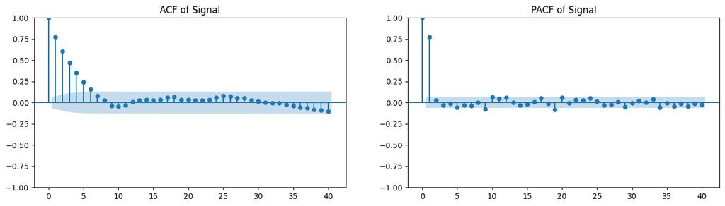

### Model Evaluation (SARIMAX)

```
Precision: 0.40963855421686746
Recall: 0.3953488372093023
F1-score: 0.40236686390532544
Confusion Matrix:
[[42 49]
 [52 34]]
```

# Random Forest

#### **Overview**

This Random Forest model is used to predict stock price signals (BUY/SELL) using **RandomizedSearchCV** for hyperparameter tuning. The goal is to maximize the **F1-score** by finding the best combination of hyperparameters.

#### **Dataset Split**

- **Features (X)**: Stock-related attributes excluding the target signal.
- **Target (y)**: Signal representing BUY/SELL decision.
- The dataset is split into **80% training** and **20% testing** sets.

#### **Hyperparameter Tuning**

- **RandomizedSearchCV** is used to optimize parameters such as:
  - **n_estimators**: Number of trees in the forest.
  - **max_depth**: Maximum depth of each tree.
  - **min_samples_split**: Minimum samples required to split a node.
  - **min_samples_leaf**: Minimum samples required at each leaf node.
  - **max_features**: Feature selection method (‘sqrt’ or ‘log2’).
  - **bootstrap**: Use of bootstrapping in training.
- **Search Space**: A broad grid is searched across **50 iterations** using **5-fold cross-validation**.

#### **Model Training & Tuning Process**

- The model is evaluated using the **F1-score** to ensure balanced precision and recall.
- **RandomizedSearchCV** leverages all available processors (`n_jobs=-1`) for efficient parallel computation.

#### **Best Hyperparameters**

After tuning, the model identifies the optimal hyperparameters for the most effective stock prediction. These parameters enhance both the model’s precision and recall in predicting stock signals.

#### **Conclusion**

The **Random Forest Classifier** with optimized hyperparameters delivers robust performance in predicting stock signals. The F1-score ensures balanced model performance, making it suitable for dynamic financial markets.

|  | signal | close | 10_DMA | cumulative_profit | debt_to_equity_ratio | price_to_book_value | other_assets | market_capitalization | research_&_development | enterprise_valuation | common_stock | property_plant_&_equipment | PC1 | PC2 | PC3 | PC4 |
| --- | --- | --- | --- | --- | --- | --- | --- | --- | --- | --- | --- | --- | --- | --- | --- | --- |
| 0 | 1 | 8.427500 | 8.427500 | 0.000000 | 0.450061 | 5.415465 | 5569000.0 | 2.130877e+08 | 426000.0 | 2.030697e+08 | 9553000.0 | 3504000.0 | 8.080048e+08 | 6.713907e+07 | -7.000018e+07 | 6.825490e+07 |
| 1 | 1 | 8.517500 | 8.472500 | 0.000000 | 0.450061 | 5.415465 | 5569000.0 | 2.130877e+08 | 426000.0 | 2.030697e+08 | 9553000.0 | 3504000.0 | 8.371229e+08 | 1.369311e+08 | -4.025388e+07 | 7.162174e+07 |
| 2 | 1 | 8.555000 | 8.500000 | 0.000000 | 0.450061 | 5.415465 | 5569000.0 | 2.130877e+08 | 426000.0 | 2.030697e+08 | 9553000.0 | 3504000.0 | 7.521293e+08 | -6.678632e+07 | -1.270810e+08 | 6.179421e+07 |
| 3 | 1 | 8.592857 | 8.523214 | 0.000000 | 0.450061 | 5.415465 | 5569000.0 | 2.130877e+08 | 426000.0 | 2.030697e+08 | 9553000.0 | 3504000.0 | 8.170795e+08 | 8.888993e+07 | -6.072967e+07 | 6.930419e+07 |
| 4 | 1 | 8.569643 | 8.532500 | 0.000000 | 0.450061 | 5.415465 | 5569000.0 | 2.130877e+08 | 426000.0 | 2.030697e+08 | 9553000.0 | 3504000.0 | 7.972125e+08 | 4.127149e+07 | -8.102530e+07 | 6.700703e+07 |
| ... | ... | ... | ... | ... | ... | ... | ... | ... | ... | ... | ... | ... | ... | ... | ... | ... |
| 2702 | 0 | 130.960007 | 126.955000 | 4631.666698 | 3.085432 | 13.914162 | 49559000.0 | 1.091218e+09 | 4565000.0 | 1.150788e+09 | 48032000.0 | 43986000.0 | -6.823723e+08 | 1.188443e+08 | -1.359444e+08 | 2.422274e+07 |
| 2703 | 0 | 131.970001 | 127.828001 | 4631.666698 | 3.085432 | 13.914162 | 49559000.0 | 1.091218e+09 | 4565000.0 | 1.150788e+09 | 48032000.0 | 43986000.0 | -6.942875e+08 | 9.028531e+07 | -1.481166e+08 | 2.284502e+07 |
| 2704 | 0 | 136.690002 | 129.256001 | 4631.666698 | 3.085432 | 13.914162 | 49559000.0 | 1.091218e+09 | 4565000.0 | 1.150788e+09 | 48032000.0 | 43986000.0 | -6.693946e+08 | 1.499500e+08 | -1.226867e+08 | 2.572331e+07 |
| 2705 | 0 | 134.869995 | 130.565000 | 4631.666698 | 3.085432 | 13.914162 | 49559000.0 | 1.091218e+09 | 4565000.0 | 1.150788e+09 | 48032000.0 | 43986000.0 | -6.706253e+08 | 1.470001e+08 | -1.239440e+08 | 2.558100e+07 |
| 2706 | 0 | 133.720001 | 131.149001 | 4631.666698 | 3.085432 | 13.914162 | 49559000.0 | 1.091218e+09 | 4565000.0 | 1.150788e+09 | 48032000.0 | 43986000.0 | -6.794275e+08 | 1.259026e+08 | -1.329361e+08 | 2.456324e+07 |

2707 rows × 16 columns

```
Fitting 5 folds for each of 50 candidates, totalling 250 fits
Best Hyperparameters: {'bootstrap': False, 'max_depth': 39, 'max_features': 'log2', 'min_samples_leaf': 2, 'min_samples_split': 2, 'n_estimators': 107}
```

### Model Evaluation (Random Forest)

#### **Confusion Matrix**

[output not shown]

#### **Conclusion**

The model shows solid overall performance with a balanced F1-score. There is room to improve precision and recall, especially for class `0` predictions.

```
Precision: 0.8145896656534954
Recall: 0.8195718654434251
F1-score: 0.8170731707317073
Confusion Matrix:
[[154  61]
 [ 59 268]]
```

|  | precision | recall | f1-score | support |
| --- | --- | --- | --- | --- |
| 0 | 0.723005 | 0.716279 | 0.719626 | 215.000000 |
| 1 | 0.814590 | 0.819572 | 0.817073 | 327.000000 |
| accuracy | 0.778598 | 0.778598 | 0.778598 | 0.778598 |
| macro avg | 0.768797 | 0.767925 | 0.768350 | 542.000000 |
| weighted avg | 0.778260 | 0.778598 | 0.778418 | 542.000000 |